# processament-dades

Lucía Martinez Margareto

```r
library(sf)
library(dplyr)
library(stringr)
library(lubridate)
library(httr)
library(jsonlite)
library(purrr)
library(terra)
library(utils)
library(arrow)
```

## Incendis

Es llisten, es descomprimeixen i es combinen els fitxers d’incendis forestals en un únic objecte espacial.

```r
zips <- list.files("dades/crues/incendis_forestals", pattern = "\\.zip$",
                   full.names = TRUE)

temp_dir <- tempdir()
for (z in zips) {
  unzip(z, exdir = temp_dir)
}

shps <- list.files(temp_dir, pattern = "\\.shp$", full.names = TRUE)
llista_sf <- lapply(shps, st_read, quiet = TRUE)
incendis <- bind_rows(llista_sf)
```

Es neteja el camp de data i es transforma a format Date, eliminant els registres sense informació temporal vàlida.

```r
incendis <- incendis %>%
  mutate(
    DATA_INCEN = str_trim(str_split(DATA_INCEN, "\r", simplify = TRUE)[,1]),
    DATA_INCEN = dmy(DATA_INCEN, quiet = TRUE)
  ) %>%
  filter(!is.na(DATA_INCEN))
```

Es valida i s’unifica la geometria dels polígons per garantir la consistència espacial.

```r
st_geometry_type(incendis) %>% table()
```

```
## .
##           GEOMETRY              POINT         LINESTRING            POLYGON
##                  0                  0                  0                 12
##         MULTIPOINT    MULTILINESTRING       MULTIPOLYGON GEOMETRYCOLLECTION
##                  0                  0                491                  0
##     CIRCULARSTRING      COMPOUNDCURVE       CURVEPOLYGON         MULTICURVE
##                  0                  0                  0                  0
##       MULTISURFACE              CURVE            SURFACE  POLYHEDRALSURFACE
##                  0                  0                  0                  0
##                TIN           TRIANGLE
##                  0                  0
```

```r
incendis <- incendis %>%
  st_make_valid() %>%
  st_cast("MULTIPOLYGON")
```

Es deriven atributs temporals i es calcula la superfície cremada per a cada incendi.

```r
estacio_any <- function(date) {
  md <- month(date)*100 + day(date)
  case_when(
    between(md, 321, 620) ~ "Primavera",
    between(md, 621, 922) ~ "Estiu",
    between(md, 923, 1220) ~ "Tardor",
    TRUE ~ "Hivern"
  )
}

incendis <- incendis %>%
  mutate(
    DIA = day(DATA_INCEN),
    MES = month(DATA_INCEN),
    ANY = year(DATA_INCEN),
    DIA_SETMANA = factor(
      wday(DATA_INCEN, week_start = 1),
      levels = 1:7,
      labels = c("dilluns", "dimarts", "dimecres", "dijous",
                 "divendres", "dissabte", "diumenge")
      ),
    TEMPORADA = factor(estacio_any(DATA_INCEN)),
    HA_CREMADES = as.numeric(st_area(geometry)) / 10000
  )
```

```r
incendis <- incendis %>%
  distinct(DATA_INCEN, geometry, .keep_all = TRUE) %>%
  dplyr::select(-GRID_CODE, -OBJECTID)
st_crs(incendis)
```

```
## Coordinate Reference System:
##   User input: ETRS89 / UTM zone 31N
##   wkt:
## PROJCRS["ETRS89 / UTM zone 31N",
##     BASEGEOGCRS["ETRS89",
##         ENSEMBLE["European Terrestrial Reference System 1989 ensemble",
##             MEMBER["European Terrestrial Reference Frame 1989"],
##             MEMBER["European Terrestrial Reference Frame 1990"],
##             MEMBER["European Terrestrial Reference Frame 1991"],
##             MEMBER["European Terrestrial Reference Frame 1992"],
##             MEMBER["European Terrestrial Reference Frame 1993"],
##             MEMBER["European Terrestrial Reference Frame 1994"],
##             MEMBER["European Terrestrial Reference Frame 1996"],
##             MEMBER["European Terrestrial Reference Frame 1997"],
##             MEMBER["European Terrestrial Reference Frame 2000"],
##             MEMBER["European Terrestrial Reference Frame 2005"],
##             MEMBER["European Terrestrial Reference Frame 2014"],
##             MEMBER["European Terrestrial Reference Frame 2020"],
##             ELLIPSOID["GRS 1980",6378137,298.257222101,
##                 LENGTHUNIT["metre",1]],
##             ENSEMBLEACCURACY[0.1]],
##         PRIMEM["Greenwich",0,
##             ANGLEUNIT["degree",0.0174532925199433]],
##         ID["EPSG",4258]],
##     CONVERSION["UTM zone 31N",
##         METHOD["Transverse Mercator",
##             ID["EPSG",9807]],
##         PARAMETER["Latitude of natural origin",0,
##             ANGLEUNIT["degree",0.0174532925199433],
##             ID["EPSG",8801]],
##         PARAMETER["Longitude of natural origin",3,
##             ANGLEUNIT["degree",0.0174532925199433],
##             ID["EPSG",8802]],
##         PARAMETER["Scale factor at natural origin",0.9996,
##             SCALEUNIT["unity",1],
##             ID["EPSG",8805]],
##         PARAMETER["False easting",500000,
##             LENGTHUNIT["metre",1],
##             ID["EPSG",8806]],
##         PARAMETER["False northing",0,
##             LENGTHUNIT["metre",1],
##             ID["EPSG",8807]]],
##     CS[Cartesian,2],
##         AXIS["(E)",east,
##             ORDER[1],
##             LENGTHUNIT["metre",1]],
##         AXIS["(N)",north,
##             ORDER[2],
##             LENGTHUNIT["metre",1]],
##     USAGE[
##         SCOPE["Engineering survey, topographic mapping."],
##         AREA["Europe between 0°E and 6°E: Andorra; Denmark - offshore; Germany - offshore; Jan Mayen - offshore; Norway including Svalbard - onshore and offshore; Spain - mainland and Balearic islands - onshore and offshore."],
##         BBOX[37,0,82.45,6.01]],
##     USAGE[
##         SCOPE["Pan-European conformal mapping at scales larger than 1:500,000."],
##         AREA["Europe between 0°E and 6°E and approximately 37°N to 82°27'N."],
##         BBOX[37,0,82.45,6.01]],
##     ID["EPSG",25831]]
```

```r
str(incendis)
```

```
## Classes 'sf' and 'data.frame':   503 obs. of  10 variables:
##  $ CODI_FINAL : chr  "2022170027" "2022170024" "165/22N" "2022080061" ...
##  $ DATA_INCEN : Date, format: "2022-02-23" "2022-02-21" ...
##  $ MUNICIPI   : chr  "SETCASES" "ROSES" "CAMARASA" "SANT PERE DE RIBES" ...
##  $ DIA        : int  23 21 1 8 10 9 7 18 30 4 ...
##  $ MES        : num  2 2 6 4 5 5 5 1 5 6 ...
##  $ ANY        : num  2022 2022 2022 2022 2022 ...
##  $ DIA_SETMANA: Factor w/ 7 levels "dilluns","dimarts",..: 3 1 3 5 2 1 6 2 1 6 ...
##  $ TEMPORADA  : Factor w/ 4 levels "Estiu","Hivern",..: 2 2 3 3 3 3 3 2 3 3 ...
##  $ HA_CREMADES: num  5.78 377.14 9.84 23.71 16.24 ...
##  $ geometry   :sfc_MULTIPOLYGON of length 503; first list element: List of 1
##   ..$ :List of 5
##   .. ..$ : num [1:285, 1:2] 438973 438978 438981 438983 438985 ...
##   .. ..$ : num [1:10, 1:2] 439031 439027 439021 439016 439020 ...
##   .. ..$ : num [1:19, 1:2] 439189 439186 439176 439167 439164 ...
##   .. ..$ : num [1:19, 1:2] 439087 439084 439080 439077 439073 ...
##   .. ..$ : num [1:23, 1:2] 439190 439193 439198 439199 439199 ...
##   ..- attr(*, "class")= chr [1:3] "XY" "MULTIPOLYGON" "sfg"
##  - attr(*, "sf_column")= chr "geometry"
##  - attr(*, "agr")= Factor w/ 3 levels "constant","aggregate",..: NA NA NA NA NA NA NA NA NA
##   ..- attr(*, "names")= chr [1:9] "CODI_FINAL" "DATA_INCEN" "MUNICIPI" "DIA" ...
```

```r
if (file.exists("dades/processades/incendis_2000_2024.gpkg"))
  file.remove("dades/processades/incendis_2000_2024.gpkg")
```

```
## [1] TRUE
```

```r
st_write(incendis, "dades/processades/incendis_2000_2024.gpkg")
```

```
## Writing layer `incendis_2000_2024' to data source
##   `dades/processades/incendis_2000_2024.gpkg' using driver `GPKG'
## Writing 503 features with 9 fields and geometry type Multi Polygon.
```

## Divisions administratives

Es descarreguen les divisions administratives a través d’un servei WFS i es carreguen com a capes espacials.

```r
wfs_url <- "https://geoserveis.icgc.cat/servei/catalunya/divisions-administratives/wfs?service=wfs&version=2.0.0&request=GetCapabilities"

# Municipis (polígons)
municipis <- st_read(
  dsn = wfs_url,
  layer = "divisions_administratives_wfs:divisions_administratives_municipis_50000"
)
# Capitals de municipis (punts)
caps_municipi <- st_read(
  dsn = wfs_url,
  layer = "divisions_administratives_wfs:divisions_administratives_capsdemunicipi_capmunicipi"
)
# Comarques (polígons)
comarques <- st_read(
  dsn = wfs_url,
  layer = "divisions_administratives_wfs:divisions_administratives_comarques_50000"
)
# Capitals de comarques (punts)
caps_comarca <- st_read(
  dsn = wfs_url,
  layer = "divisions_administratives_wfs:divisions_administratives_capsdemunicipi_capcomarca"
)
# Províncies (polígons)
provincies <- st_read(
  dsn = wfs_url,
  layer = "divisions_administratives_wfs:divisions_administratives_provincies_50000"
)
```

Guardat cru en GPKG

```r
datasets <- list(
  municipis = municipis,
  caps_municipi = caps_municipi,
  comarques = comarques,
  caps_comarca = caps_comarca,
  provincies = provincies)

for (nm in names(datasets)) {
  st_write(datasets[[nm]], paste0("dades/crues/divisions_admin/", nm, ".gpkg"),
           layer = nm, delete_layer = TRUE)
}
```

```
## Deleting layer `municipis' using driver `GPKG'
## Writing layer `municipis' to data source
##   `dades/crues/divisions_admin/municipis.gpkg' using driver `GPKG'
## Writing 947 features with 17 fields and geometry type Multi Surface.
## Deleting layer `caps_municipi' using driver `GPKG'
## Writing layer `caps_municipi' to data source
##   `dades/crues/divisions_admin/caps_municipi.gpkg' using driver `GPKG'
## Writing 947 features with 10 fields and geometry type Point.
## Deleting layer `comarques' using driver `GPKG'
## Writing layer `comarques' to data source
##   `dades/crues/divisions_admin/comarques.gpkg' using driver `GPKG'
## Writing 43 features with 8 fields and geometry type Multi Surface.
## Deleting layer `caps_comarca' using driver `GPKG'
## Writing layer `caps_comarca' to data source
##   `dades/crues/divisions_admin/caps_comarca.gpkg' using driver `GPKG'
## Writing 44 features with 10 fields and geometry type Point.
## Deleting layer `provincies' using driver `GPKG'
## Writing layer `provincies' to data source
##   `dades/crues/divisions_admin/provincies.gpkg' using driver `GPKG'
## Writing 4 features with 8 fields and geometry type Multi Surface.
```

Se seleccionen únicament les variables rellevants per reduir la complexitat dels conjunts de dades.

```r
municipis_norm <- municipis %>%
  dplyr::select(CODIMUNI, NOMMUNI, CAPMUNI, CODICOMAR, CODIPROV,
         SHAPE_Area, SHAPE)

caps_municipi_norm <- caps_municipi %>%
  dplyr::select(OBJECTID, NOMCAP, CODIMUNI, SHAPE)

comarques_norm <- comarques %>%
  dplyr::select(CODICOMAR, NOMCOMAR, CAPCOMAR, SHAPE_Area,
         SHAPE)

caps_comarca_norm <- caps_comarca %>%
  dplyr::select(OBJECTID, NOMCAP, CODICOMAR, SHAPE)

provincies_norm <- provincies %>%
  dplyr::select(CODIPROV, NOMPROV, CAPPROV, SHAPE_Area, SHAPE)
```

Guardat processat en GPKG

```r
datasets2 <- list(
  municipis_norm = municipis_norm,
  caps_municipi_norm = caps_municipi_norm,
  comarques_norm = comarques_norm,
  caps_comarca_norm = caps_comarca_norm,
  provincies_norm = provincies_norm)

for (nm in names(datasets2)) {
  st_write(datasets2[[nm]], paste0("dades/processades/divisions_admin/", nm, ".gpkg"),
           layer = nm, delete_layer = TRUE)
}
```

```
## Deleting layer `municipis_norm' using driver `GPKG'
## Writing layer `municipis_norm' to data source
##   `dades/processades/divisions_admin/municipis_norm.gpkg' using driver `GPKG'
## Writing 947 features with 6 fields and geometry type Multi Surface.
## Deleting layer `caps_municipi_norm' using driver `GPKG'
## Writing layer `caps_municipi_norm' to data source
##   `dades/processades/divisions_admin/caps_municipi_norm.gpkg' using driver `GPKG'
## Writing 947 features with 3 fields and geometry type Point.
## Deleting layer `comarques_norm' using driver `GPKG'
## Writing layer `comarques_norm' to data source
##   `dades/processades/divisions_admin/comarques_norm.gpkg' using driver `GPKG'
## Writing 43 features with 4 fields and geometry type Multi Surface.
## Deleting layer `caps_comarca_norm' using driver `GPKG'
## Writing layer `caps_comarca_norm' to data source
##   `dades/processades/divisions_admin/caps_comarca_norm.gpkg' using driver `GPKG'
## Writing 44 features with 3 fields and geometry type Point.
## Deleting layer `provincies_norm' using driver `GPKG'
## Writing layer `provincies_norm' to data source
##   `dades/processades/divisions_admin/provincies_norm.gpkg' using driver `GPKG'
## Writing 4 features with 4 fields and geometry type Multi Surface.
```

## Cremes controlades

Es filtren les cremes controlades dins del període d’estudi i s’eliminen duplicats geomètrics.

```r
cremes <- st_read("dades/crues/cremes/CremesCAT.shp")
cremes <- cremes %>%
  distinct(DATA_CREMA, geometry, .keep_all = TRUE) %>%
  dplyr::select(DATA_CREMA, HECTARES, geometry) %>%
  filter(DATA_CREMA > as.Date("1999-12-31"))
```

```r
if (file.exists("dades/processades/cremes.gpkg"))
  file.remove("dades/processades/cremes.gpkg")
```

```
## [1] TRUE
```

```r
st_write(cremes, "dades/processades/cremes.gpkg")
```

```
## Writing layer `cremes' to data source
##   `dades/processades/cremes.gpkg' using driver `GPKG'
## Writing 544 features with 2 fields and geometry type Multi Polygon.
```

## Estacions meteorològiques

Es netegen els formats, es converteixen les dates i es transforma la geometria al sistema de referència UTM.

```r
estacions <- read.csv("dades/crues/XEMA/estacions.csv", dec = ",")
estacions$ALTITUD <- gsub("\\.", ",", gsub(",", "", estacions$ALTITUD))
estacions <- estacions %>%
  mutate(DATA_ALTA = as.Date(DATA_ALTA, format = "%d/%m/%Y"),
         DATA_BAIXA = as.Date(DATA_BAIXA, format = "%d/%m/%Y")) %>%
  distinct() %>%
  dplyr::select(CODI_ESTACIO, DATA_ALTA, DATA_BAIXA, Georeferència)
str(estacions)
```

```
## 'data.frame':    245 obs. of  4 variables:
##  $ CODI_ESTACIO : chr  "WZ" "Z1" "YX" "CN" ...
##  $ DATA_ALTA    : Date, format: "2006-06-27" "1997-11-06" ...
##  $ DATA_BAIXA   : Date, format: NA NA ...
##  $ Georeferència: chr  "POINT (1.63346 41.20187)" "POINT (0.98486 42.64691)" "POINT (0.31688 41.08307)" "POINT (1.87672 42.22903)" ...
```

```r
estacions_sf <- st_sf(estacions, geometry = st_as_sfc(estacions$Georeferència),
                      crs = 4326)
estacions_utm31n <- st_transform(estacions_sf, crs = 25831)
estacions_utm31n <- estacions_utm31n %>%
  dplyr::select(-Georeferència)
```

```r
if (file.exists("dades/processades/estacions_utm31n.gpkg"))
  file.remove("dades/processades/estacions_utm31n.gpkg")
```

```
## [1] TRUE
```

```r
st_write(estacions_utm31n, "dades/processades/estacions_utm31n.gpkg")
```

```
## Writing layer `estacions_utm31n' to data source
##   `dades/processades/estacions_utm31n.gpkg' using driver `GPKG'
## Writing 245 features with 3 fields and geometry type Point.
```

## Meteorologia

Es corregeixen els formats, es transformen les dates i es filtren els registres representatius.

```r
meteorologia <- read.csv("dades/crues/XEMA/meteorologia.csv", dec = ",")
meteorologia$CODI_VARIABLE <- as.integer(gsub("\\.", "", meteorologia$CODI_VARIABLE))
meteorologia <- meteorologia %>%
  mutate(DATA_LECTURA = as.Date(DATA_LECTURA, format = "%d/%m/%Y")) %>%
  distinct() %>%
  filter(Estat == "Representatiu") %>%
  dplyr::select(-NOM_ESTACIO, -UNITAT, -HORA._TU, -Estat)
str(meteorologia)
```

```
## 'data.frame':    8989958 obs. of  6 variables:
##  $ ID           : chr  "C61400122431" "C61001122431" "C61102122431" "C61300122431" ...
##  $ CODI_ESTACIO : chr  "C6" "C6" "C6" "C6" ...
##  $ DATA_LECTURA : Date, format: "2024-12-31" "2024-12-31" ...
##  $ CODI_VARIABLE: int  1400 1001 1102 1300 1700 1515 1512 1503 1400 1300 ...
##  $ NOM_VARIABLE : chr  "Irradiació solar global diària" "Temperatura màxima diària + hora" "Humitat relativa mínima diària + data" "Precipitació acumulada diària" ...
##  $ VALOR        : num  1.2 0.7 95 0 0.84 131 6.6 1.6 9.2 0 ...
```

```r
if (file.exists("dades/processades/meteorologia.parquet"))
  file.remove("dades/processades/meteorologia.parquet")
```

```
## [1] TRUE
```

```r
write_parquet(meteorologia, "dades/processades/meteorologia.parquet")
```

## Model d’elevacions

Es descomprimeixen, es carreguen i es combinen els fitxers raster per generar un model digital d’elevacions continu. Es descarten els valors negatius que corresponen a zones sota el nivell del mar.

```r
zip_dir <- "dades/crues/mde5x5"

temp_dir <- file.path(tempdir(), "dem_unzip")
dir.create(temp_dir, showWarnings = FALSE)

zip_files <- list.files(zip_dir, pattern = "\\.zip$", full.names = TRUE)

descomprimir_zip <- function(zip_path, out_dir) {
  unzip(zip_path, exdir = out_dir)
}

# Descompressió primer nivell
for (z in zip_files) {
  carpeta_zip <- file.path(temp_dir, tools::file_path_sans_ext(basename(z)))
  dir.create(carpeta_zip, showWarnings = FALSE)
  descomprimir_zip(z, carpeta_zip)
}

# Descompressió segon nivell
zip_files_2 <- list.files(temp_dir, pattern = "\\.zip$", full.names = TRUE, recursive = TRUE)

final_dir <- file.path(temp_dir, "final_txt")
dir.create(final_dir, showWarnings = FALSE)

for (z2 in zip_files_2) {
  unzip(z2, exdir = final_dir)
}

txt_files <- list.files(final_dir, pattern = "\\.txt$", full.names = TRUE)
rasters <- lapply(txt_files, rast)
mosaic_dem <- do.call(merge, rasters)
```

```
## |---------|---------|---------|---------|=========================================
```

```r
mosaic_dem[mosaic_dem < 0] <- NA
```

```
## |---------|---------|---------|---------|=========================================                                          |---------|---------|---------|---------|=========================================
```

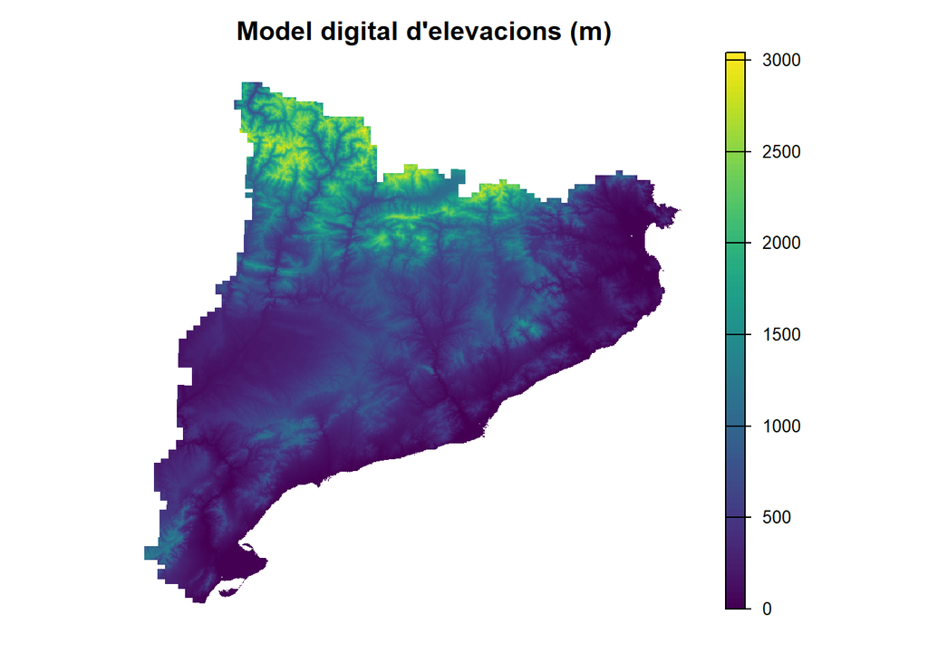

```r
plot(mosaic_dem, axes = FALSE, main = "Model digital d'elevacions (m)")
```

```r
writeRaster(mosaic_dem, "dades/processades/MDT5x5.tif", overwrite = TRUE)
```

```
## |---------|---------|---------|---------|=========================================
```

## Pendent i orientació

Es deriven les capes de pendent i orientació a partir del model digital d’elevacions.

```r
pendent <- terrain(mosaic_dem, v = "slope", unit = "degrees")
```

```
## |---------|---------|---------|---------|=========================================
```

```r
orientacio <- terrain(mosaic_dem, v = "aspect", unit = "degrees")
```

```
## |---------|---------|---------|---------|=========================================
```

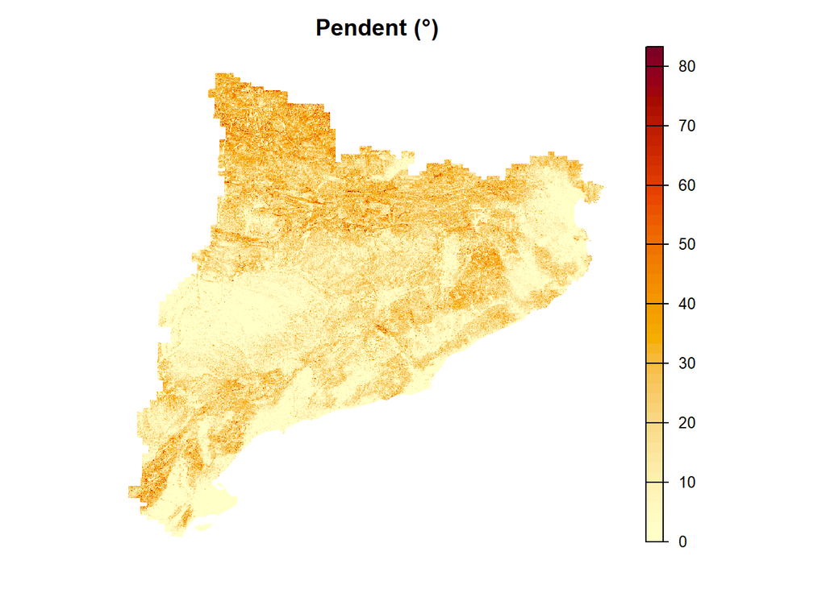

```r
plot(pendent, col = rev(hcl.colors(50, "YlOrRd")),
     axes = FALSE, main = "Pendent (°)")
```

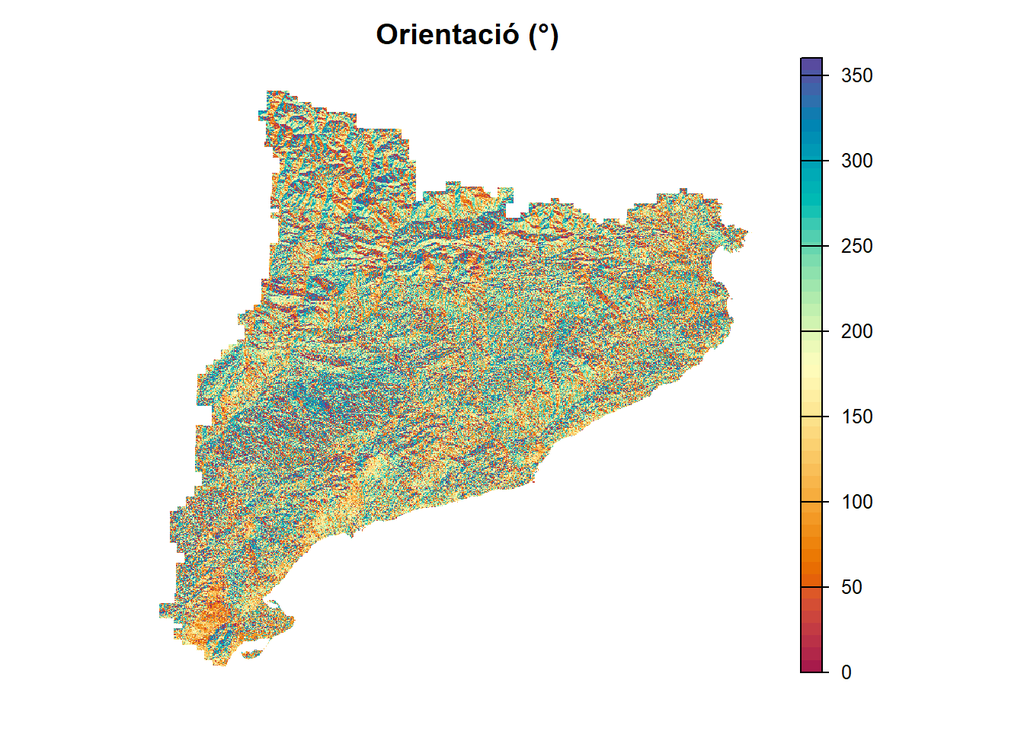

```r
plot(orientacio, col = hcl.colors(50, "Spectral"),
     axes = FALSE, main = "Orientació (°)")
```

```r
writeRaster(pendent, "dades/processades/pendent.tif", overwrite = TRUE)
```

```
## |---------|---------|---------|---------|=========================================
```

```r
writeRaster(orientacio, "dades/processades/orientacio.tif", overwrite = TRUE)
```

```
## |---------|---------|---------|---------|=========================================
```

## Cobertes del sòl

S’exploren les capes i es carreguen tant les cobertes del sòl com les seves categories.

```r
st_layers("dades/crues/cobertes_sol/cobertes-sol-v1r0-2009.gpkg")
```

```
## Driver: GPKG
## Available layers:
##                layer_name geometry_type features fields              crs_name
## 1            cobertes_sol       Polygon  1537659      2 ETRS89 / UTM zone 31N
## 2 cobertes_sol_categories            NA       41      3                  <NA>
## 3            layer_styles            NA        2     12                  <NA>
```

```r
st_layers("dades/crues/cobertes_sol/cobertes-sol-v1r0-2018.gpkg")
```

```
## Driver: GPKG
## Available layers:
##                layer_name geometry_type features fields
## 1            layer_styles                      1     12
## 2 cobertes_sol_categories                     41      3
## 3            cobertes_sol                1526984      3
##                   crs_name
## 1 Undefined geographic SRS
## 2 Undefined geographic SRS
## 3    ETRS89 / UTM zone 31N
```

```r
st_layers("dades/crues/cobertes_sol/cobertes-sol-v1r0-2019-2022.gpkg")
```

```
## Driver: GPKG
## Available layers:
##                layer_name geometry_type features fields
## 1            layer_styles                      1     12
## 2            cobertes_sol                1541167      2
## 3 cobertes_sol_categories            NA       41      3
##                   crs_name
## 1 Undefined geographic SRS
## 2    ETRS89 / UTM zone 31N
## 3                     <NA>
```

```r
st_layers("dades/crues/cobertes_sol/cobertes-sol-v1r0-2023.gpkg")
```

```
## Driver: GPKG
## Available layers:
##                layer_name geometry_type features fields
## 1            layer_styles                      1     12
## 2            cobertes_sol                1539872      2
## 3 cobertes_sol_categories            NA       41      3
##                   crs_name
## 1 Undefined geographic SRS
## 2    ETRS89 / UTM zone 31N
## 3                     <NA>
```

```r
cobertes2009 <- st_read("dades/crues/cobertes_sol/cobertes-sol-v1r0-2009.gpkg",
                        layer = "cobertes_sol")
cobertes2018 <- st_read("dades/crues/cobertes_sol/cobertes-sol-v1r0-2018.gpkg",
                        layer = "cobertes_sol")
cobertes2019_2022 <- st_read("dades/crues/cobertes_sol/cobertes-sol-v1r0-2019-2022.gpkg",
                             layer = "cobertes_sol")
cobertes2023 <- st_read("dades/crues/cobertes_sol/cobertes-sol-v1r0-2023.gpkg",
                        layer = "cobertes_sol")
cat_2009 <- st_read(
  "dades/crues/cobertes_sol/cobertes-sol-v1r0-2009.gpkg",
  layer = "cobertes_sol_categories",
  quiet = TRUE
)
cat_2018 <- st_read(
  "dades/crues/cobertes_sol/cobertes-sol-v1r0-2018.gpkg",
  layer = "cobertes_sol_categories",
  quiet = TRUE
)
cat_2019_2022 <- st_read(
  "dades/crues/cobertes_sol/cobertes-sol-v1r0-2019-2022.gpkg",
  layer = "cobertes_sol_categories",
  quiet = TRUE
)
cat_2023 <- st_read(
  "dades/crues/cobertes_sol/cobertes-sol-v1r0-2023.gpkg",
  layer = "cobertes_sol_categories",
  quiet = TRUE
)
```

Es reclassifiquen segons el tipus de cobertura i el nivell de combustible.

```r
processar_cobertes <- function(entrada, path_sortida) {
  cobertes <- entrada

  cobertes <- cobertes %>%
    mutate(
      TIPUS = case_when(
        nivell_2 %in% c(111:116) ~ "Agrícola",
        nivell_2 %in% c(221:223) ~ "Forest_tancat",
        nivell_2 %in% c(225:227, 229) ~ "Forest_obert",
        nivell_2 == 224 ~ "Matollar",
        nivell_2 == 228 ~ "Herbaci",
        nivell_2 %in% c(230:233) ~ "Sense_vegetació",
        nivell_2 %in% c(234, 461:466) ~ "Aigua",
        nivell_2 %in% c(341:355) ~ "Infraestructures",
        TRUE ~ NA_character_
      ),
      COMBUST = case_when(
        nivell_2 %in% c(221:224) ~ "Alta",
        nivell_2 %in% c(225:229) ~ "Mitjana",
        nivell_2 %in% c(111:116, 346) ~ "Baixa",
        TRUE ~ "No_comb"
      )
    )

  st_write(cobertes, path_sortida, delete_layer = TRUE)
}

arxius_entrada <- list(cobertes2009, cobertes2018, cobertes2019_2022, cobertes2023)

arxius_sortida <- c(
  "dades/processades/cobertes_sol/cobertes-sol-v1r0-2009-reclas.gpkg",
  "dades/processades/cobertes_sol/cobertes-sol-v1r0-2018-reclas.gpkg",
  "dades/processades/cobertes_sol/cobertes-sol-v1r0-2019-2022-reclas.gpkg",
  "dades/processades/cobertes_sol/cobertes-sol-v1r0-2023-reclas.gpkg"
)

for(i in seq_along(arxius_entrada)) {
  processar_cobertes(arxius_entrada[[i]], arxius_sortida[i])
}
```

```
## Deleting layer `cobertes-sol-v1r0-2009-reclas' using driver `GPKG'
## Writing layer `cobertes-sol-v1r0-2009-reclas' to data source
##   `dades/processades/cobertes_sol/cobertes-sol-v1r0-2009-reclas.gpkg' using driver `GPKG'
## Writing 1537659 features with 4 fields and geometry type Polygon.
## Deleting layer `cobertes-sol-v1r0-2018-reclas' using driver `GPKG'
## Writing layer `cobertes-sol-v1r0-2018-reclas' to data source
##   `dades/processades/cobertes_sol/cobertes-sol-v1r0-2018-reclas.gpkg' using driver `GPKG'
## Writing 1526984 features with 5 fields and geometry type Polygon.
## Deleting layer `cobertes-sol-v1r0-2019-2022-reclas' using driver `GPKG'
## Writing layer `cobertes-sol-v1r0-2019-2022-reclas' to data source
##   `dades/processades/cobertes_sol/cobertes-sol-v1r0-2019-2022-reclas.gpkg' using driver `GPKG'
## Writing 1541167 features with 4 fields and geometry type Polygon.
## Deleting layer `cobertes-sol-v1r0-2023-reclas' using driver `GPKG'
## Writing layer `cobertes-sol-v1r0-2023-reclas' to data source
##   `dades/processades/cobertes_sol/cobertes-sol-v1r0-2023-reclas.gpkg' using driver `GPKG'
## Writing 1539872 features with 4 fields and geometry type Polygon.
```

## Espais naturals

Es descomprimeixen i es carreguen les capes d’espais naturals, se seleccionen les variables rellevants i es guarden com a fitxers processats.

```r
zip_dir <- "dades/crues/espais_naturals"

temp_dir <- file.path(tempdir(), "shp_unzip")
dir.create(temp_dir, showWarnings = FALSE)

zip_files <- list.files(zip_dir, pattern = "\\.zip$", full.names = TRUE)

for (z in zip_files) {
  carpeta_zip <- file.path(temp_dir, tools::file_path_sans_ext(basename(z)))
  dir.create(carpeta_zip, showWarnings = FALSE)
  unzip(z, exdir = carpeta_zip)
}

shp_files <- list.files(temp_dir, pattern = "\\.shp$", recursive = TRUE,
                        full.names = TRUE)

fitxer_pein <- shp_files[str_detect(shp_files, fixed("PEIN", ignore_case = TRUE))]
pein <- st_read(fitxer_pein, quiet = TRUE)

fitxer_xarnat <- shp_files[str_detect(shp_files, fixed("XARNAT_2000", ignore_case = TRUE))]
xarnat <- st_read(fitxer_xarnat, quiet = TRUE)

fitxer_enpe <- shp_files[str_detect(shp_files, fixed("ENPE", ignore_case = TRUE))]
enpe <- st_read(fitxer_enpe, quiet = TRUE)
```

```r
pein <- pein %>% select(AMBIT, AREA_HA, CODI_PEIN, NOM_PEIN, geometry)
xarnat <- xarnat %>% select(AMBIT, AREA_HA, CODI_XN2, NOM_XN2, LIC_ZEC, ZEPA, geometry)
enpe <- enpe %>% select(AMBIT, AREA_HA, CODI_ESPAI, NOM_ESPAI, geometry)
```

```r
dir_sortida <- "dades/processades/espais_naturals/"
if (!dir.exists(dir_sortida)) dir.create(dir_sortida, recursive = TRUE)

st_write(pein, file.path(dir_sortida, "PEIN.gpkg"), delete_layer = TRUE)
```

```
## Deleting layer `PEIN' using driver `GPKG'
## Writing layer `PEIN' to data source
##   `dades/processades/espais_naturals//PEIN.gpkg' using driver `GPKG'
## Writing 749 features with 4 fields and geometry type Polygon.
```

```r
st_write(xarnat, file.path(dir_sortida, "XARNAT_2000.gpkg"), delete_layer = TRUE)
```

```
## Deleting layer `XARNAT_2000' using driver `GPKG'
## Writing layer `XARNAT_2000' to data source
##   `dades/processades/espais_naturals//XARNAT_2000.gpkg' using driver `GPKG'
## Writing 663 features with 6 fields and geometry type Multi Polygon.
```

```r
st_write(enpe, file.path(dir_sortida, "ENPE.gpkg"), delete_layer = TRUE)
```

```
## Deleting layer `ENPE' using driver `GPKG'
## Writing layer `ENPE' to data source
##   `dades/processades/espais_naturals//ENPE.gpkg' using driver `GPKG'
## Writing 385 features with 4 fields and geometry type Polygon.
```